# Identification of epigenetic modifiers of neuroblastoma

## *CCBR-482*

#### *August 22, 2015*

## **Background**

Neuroblastoma (NB) is a rare childhood cancer affecting 10.2 cases per million children under 15 years of age in the United States. The median age at diagnosis is 17 months, being the most common cancer diagnosed in the first year of life.

The epigenotype of neuroblastoma is still poorly understood. Present literature on neuroblastoma and our in house experiments clearly states that MYCN and EZH2 are essential epigenetic modulators, shaping the biology of NB. With the discovery of super-enhancers and their functional importance in cancer, it is tempting to hypothesize that MYCN the master regulator of NB, binds to super-enhancers, along with other crucial transcription factors, thus determining the cell fate. The Polycomb Repressor Complex (PRC2) subunit EZH2 along with MYCN is expected to be another critical epigenetic modifier binding the super-enhancers.

Gene Expression and Chip-Seq experiments will be carried out on KCNR cells (MYCN amplified) at steady state or after treatment with Retinoic acid.

## **Data Processing**

#### *This part of the program was run on biowulf, and data transferred to a local directory*

```r
gtf="gencode.v19.annotation.gtf"
targets <- readTargets()
fc <- featureCounts(files=targets$bam,isGTFAnnotationFile=TRUE,nthreads=32,
      annot.ext=gtf,GTF.attrType="gene_name",strandSpecific=2,isPairedEnd=TRUE)
x <- DGEList(counts=fc$counts, genes=fc$annotation)
```

#### *Load data from local directory:*

```r
load("data/Gencode_fc_downsamp.RData")
fc1=mat=fc$counts
tfc1=t(fc1)
filter <- apply(fc1, 1, function(x) length(x[x>5])>=1)
fc1filt <- fc1[filter,]
genes <- rownames(fc1filt)
```

#### *QC Check: Look at raw signal distribution and median expression levels*

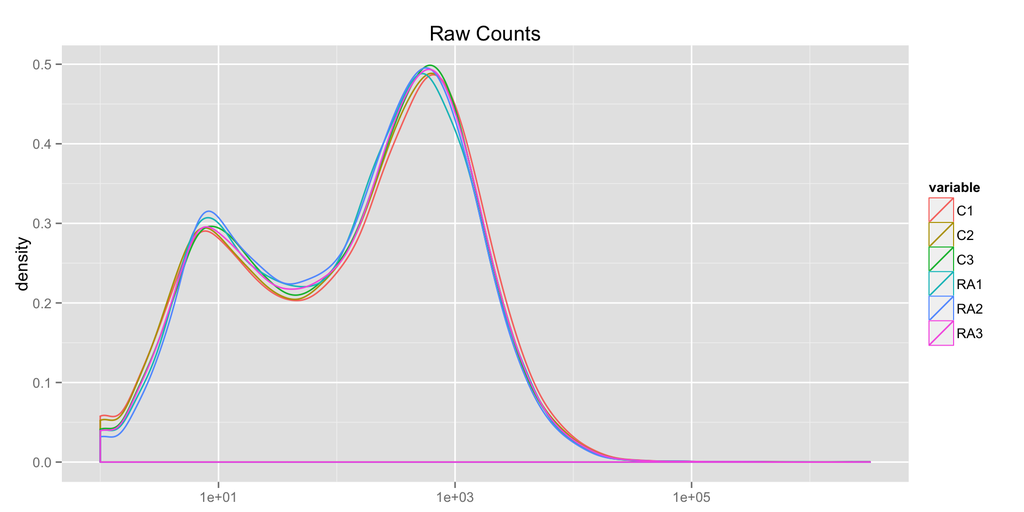

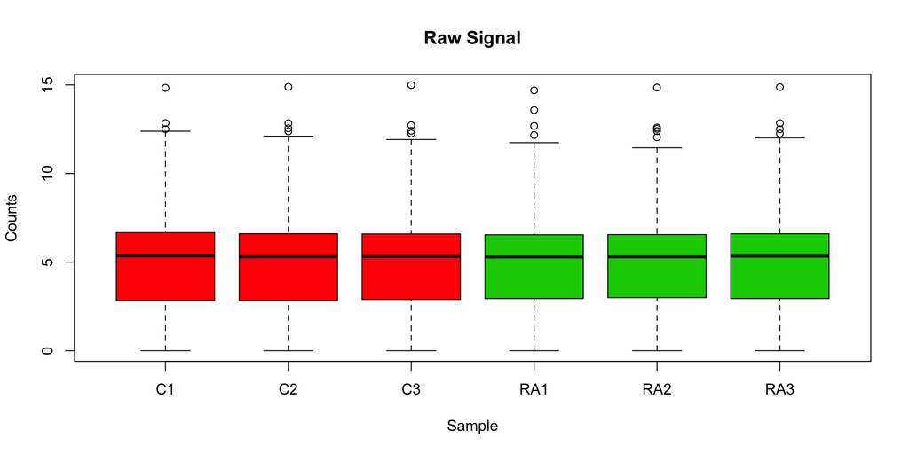

#### *Data is converted to cpm and further normalized by quantile normalization*

```r
x <- DGEList(counts=fc$counts, genes=fc$annotation)
isexpr <- rowSums(cpm(x)>1) >= 2
hasannot <- rowSums(is.na(x$genes))==0
x <- x[isexpr & hasannot,keep.lib.sizes=FALSE]

dim(x)
```

```
## [1] 14163     6
```

```r
x <- calcNormFactors(x)
targets$replicate=c(1,2,3,1,2,3)
celltype <- factor(targets$condition)
Replicate <- factor(targets$replicate)
cell_rep=paste(celltype,Replicate,sep=".")
design <- model.matrix(~Replicate+celltype)
design
```

```
##   (Intercept) Replicate2 Replicate3 celltypeRA
## 1           1          0          0          0
## 2           1          1          0          0
## 3           1          0          1          0
## 4           1          0          0          1
## 5           1          1          0          1
## 6           1          0          1          1
## attr(,"assign")
## [1] 0 1 1 2
## attr(,"contrasts")
## attr(,"contrasts")$Replicate
## [1] "contr.treatment"
##
## attr(,"contrasts")$celltype
## [1] "contr.treatment"
```

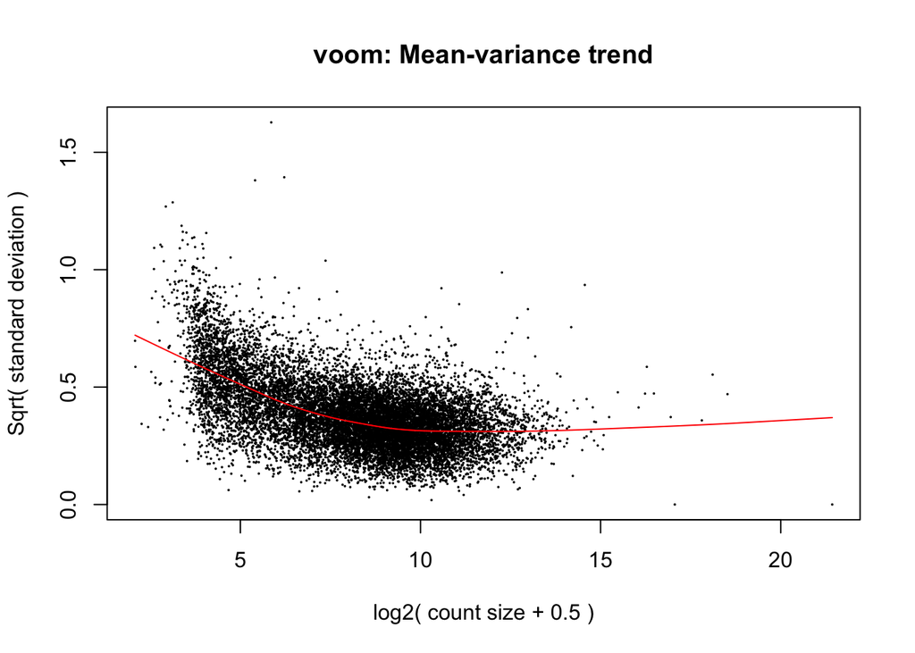

```r
v <- voom(as.matrix(x),design,plot=TRUE,normalize="quantile")
```

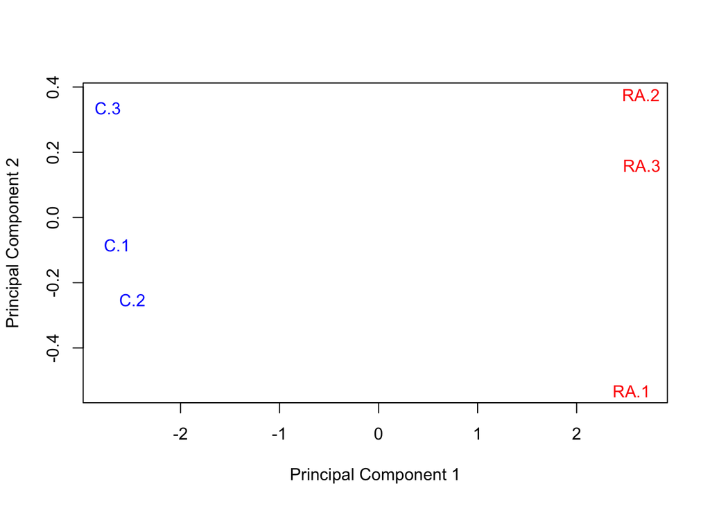

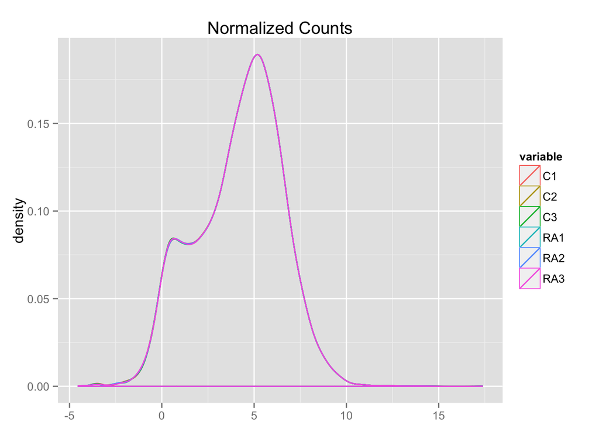

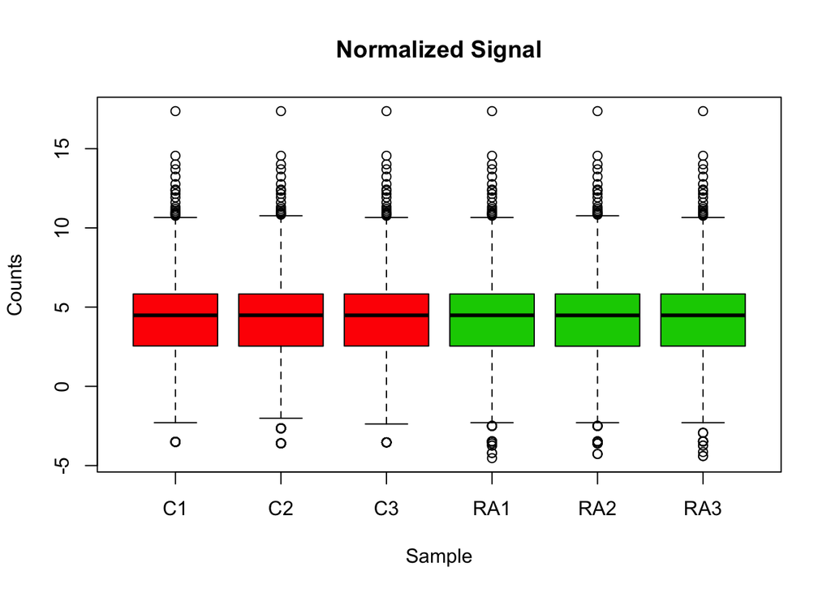

```r
plotMDS(v,top=50,labels=substring(cell_rep,1,4),
      col=ifelse(celltype=="C","blue","red"),gene.selection="common")
```

#### *QC Check: Known effect of RA on MYCN Expression*

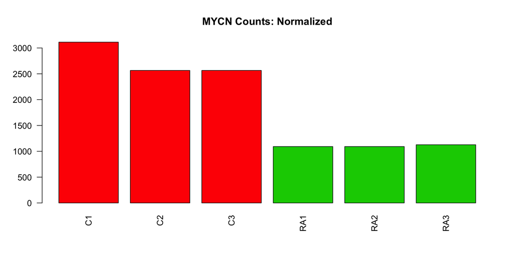

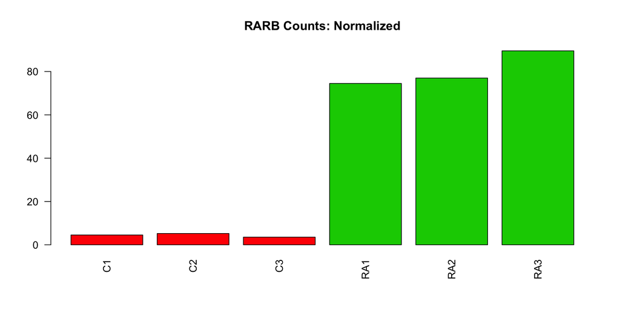

```r
fit <- lmFit(v,design)
fit <- eBayes(fit)
options(digits=3)
topgenes=topTable(fit,coef=4,n=50,sort="p")
topgenes
```

```
##            logFC AveExpr     t  P.Value adj.P.Val    B
## CRABP2      5.73   6.826  49.9 1.24e-13  1.75e-09 21.4
## PLK2        3.69   6.887  43.2 5.49e-13  3.89e-09 20.3
## CLMN        4.47   5.579  39.2 1.47e-12  6.65e-09 19.2
## NTRK2       3.65   5.904  38.3 1.90e-12  6.65e-09 19.1
## PLAT        4.76   4.493  37.5 2.35e-12  6.65e-09 18.5
## RET         3.85   9.192  35.4 4.17e-12  9.84e-09 18.5
## H19         2.72   7.711  31.6 1.34e-11  2.71e-08 17.3
## CORIN       2.83   4.670  26.7 7.33e-11  1.03e-07 15.6
## CNN2        3.72   3.670  26.7 7.57e-11  1.03e-07 15.4
## DLG2        4.19   3.294  26.6 7.68e-11  1.03e-07 15.2
## HIC1        6.41   2.785  26.1 9.47e-11  1.03e-07 14.2
## RARB        4.18   4.229  26.0 9.59e-11  1.03e-07 15.3
## HEY1        2.42   5.719  26.0 9.62e-11  1.03e-07 15.4
## SULF2      -2.53   5.622 -25.8 1.07e-10  1.03e-07 15.3
## FAM63B      2.17   6.411  25.6 1.12e-10  1.03e-07 15.2
## TNR         3.69   4.070  25.5 1.19e-10  1.03e-07 15.1
## DHRS3       9.57   1.643  25.4 1.24e-10  1.03e-07 12.7
## ENPP2       2.07   8.620  24.8 1.59e-10  1.19e-07 14.9
## GATA6       2.67   4.358  24.8 1.59e-10  1.19e-07 14.9
## RBP1        2.17   6.872  24.6 1.71e-10  1.19e-07 14.8
## ARMC9       2.24   5.441  24.5 1.77e-10  1.19e-07 14.8
## FN1         2.19   5.586  24.3 1.91e-10  1.19e-07 14.7
## SCGN        2.41   5.183  24.2 2.01e-10  1.19e-07 14.6
## NFKBIZ      3.25   3.606  24.2 2.01e-10  1.19e-07 14.6
## ASIC4       5.84   2.149  23.7 2.54e-10  1.44e-07 13.3
## AC017048.3  2.55   4.740  23.1 3.26e-10  1.70e-07 14.2
## GNG2        1.95   8.469  23.1 3.27e-10  1.70e-07 14.1
## PLEKHA6     2.22   8.492  23.0 3.37e-10  1.70e-07 14.1
## CYP26A1     8.72   1.466  22.7 3.93e-10  1.90e-07 12.1
## EGR1        3.42   3.159  22.6 4.03e-10  1.90e-07 13.8
## INSM2      -3.56   4.139 -22.2 4.88e-10  2.23e-07 13.7
## SORL1       2.14   6.927  21.9 5.61e-10  2.48e-07 13.6
## OSBPL10     1.85   5.991  21.7 6.14e-10  2.56e-07 13.5
## NIPAL1      4.64   2.122  21.7 6.16e-10  2.56e-07 12.9
## CYP26B1    10.54   3.304  21.6 6.46e-10  2.61e-07 12.0
## FNDC5       5.33   1.999  21.5 6.72e-10  2.64e-07 12.6
## NRXN1       1.84   6.481  21.0 8.34e-10  3.19e-07 13.2
## EFNB2       1.81   5.644  20.9 8.76e-10  3.27e-07 13.1
## NTRK1       2.19   6.242  20.8 9.25e-10  3.36e-07 13.1
## PDE11A      5.49   1.696  20.6 1.02e-09  3.61e-07 12.1
## SNCAIP      2.51   4.325  20.4 1.12e-09  3.70e-07 12.9
## NR0B1       7.22   2.426  20.4 1.17e-09  3.70e-07 11.9
## TOX        -3.40   2.926 -20.3 1.18e-09  3.70e-07 12.8
## MAP1A       1.77   6.371  20.3 1.18e-09  3.70e-07 12.8
## CHRM2      -2.05   5.038 -20.3 1.19e-09  3.70e-07 12.8
## FLNB        1.83   8.356  20.3 1.20e-09  3.70e-07 12.8
## HEBP2       2.18   4.359  20.2 1.28e-09  3.84e-07 12.8
## RARA        1.86   5.688  20.1 1.30e-09  3.84e-07 12.7
## CRYGC       6.72  -0.187  20.1 1.35e-09  3.90e-07 11.2
## MFAP4      -2.00   5.633 -19.9 1.49e-09  4.21e-07 12.6
```

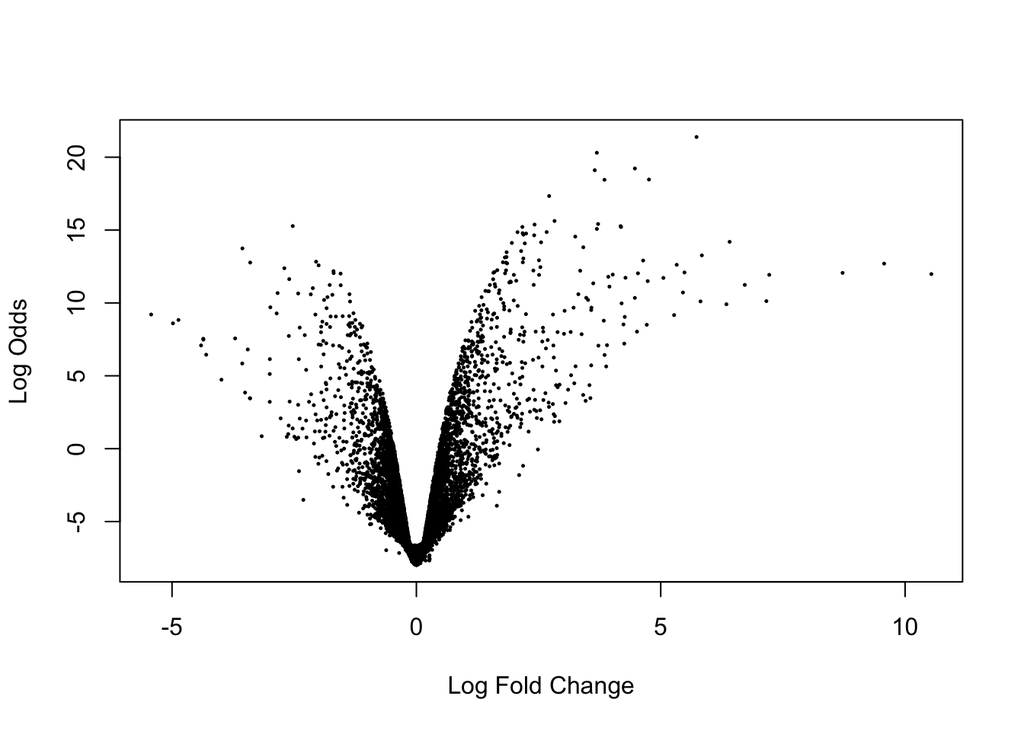

```r
volcanoplot(fit,coef=4)
```

```r
FC = 2^(fit$coefficients[,4])
FC = ifelse(FC<1,-1/FC,FC)
```

```r
library(googleVis)
op <- options(gvis.plot.tag='chart')
```

```r
## Set options back to original options
options(op)
```

```r
library(d3heatmap)
topgenes_data=v$E[rownames(v$E) %in% rownames(topgenes),]
d3heatmap(topgenes_data, scale = "column", dendrogram = "none",
    color = "YlOrRd")
```

[interactive chart not shown]